# Introduction to MAF

Joshua Lin, Christopher Kim, Erika Li, Jeanne Revilla, Mahija Mogalipuvvu, adapted from Nicole Black, Wade Boohar

07/17/22

*Deliverables* - upload this R Notebook to your GitHub and submit the link to your Repo on Brightspace - include ALL graphs or figures created in this assignment in a folder with your R notebook with descriptive file names.

We encourage you to work with a partner. Therefore, it is okay if your answers are the same as your partner’s as long as everyone understands it and could explain it in their own words if asked. Each person must individually push their code to Github. *If you do work with a partner, at the top of your R Notebook, write the name of you and your partner(s) as a comment.*

*Complete the following coding activity and answer any following questions as comments in your R Notebook*

In this assignment, you will need to use your skills learned in class to demonstrate your understanding of categorical variables and R data structures.

*Pre-Assignment* Load all necessary packages, read in the clinical data.csv file you have in your analysis_data folder, and instantiate the MAF_object.

```r
# Name: Rei Shuen Ng

if (!require("BiocManager", quietly = TRUE)) install.packages("BiocManager")
if (!require("TCGAbiolinks", quietly = TRUE)) BiocManager::install("TCGAbiolinks")
if (!require("maftools", quietly = TRUE)) BiocManager::install("maftools")
for (pkg in c("survival", "survminer", "ggplot2")) if (!require(pkg, character.only = TRUE)) install.packages(pkg)
library(TCGAbiolinks)
library(maftools)
library(survival)
library(survminer)
library(ggplot2)

# Local paths: change these two lines if your folders are elsewhere
data_dir <- normalizePath("~/qbio_490/analysis_data", mustWork = FALSE)   # TCGA data (outside the repo)
fig_dir  <- normalizePath("~/qbio_490/qbio_490_reishuen_ng/week6_genomics", mustWork = FALSE) # this notebook's folder; figures go here
dir.create(file.path(fig_dir, "figures"), showWarnings = FALSE)

clinic <- read.csv(file.path(data_dir, "brca_clinical_data.csv"))
colnames(clinic)[colnames(clinic) == "bcr_patient_barcode"] <- "Tumor_Sample_Barcode" # only needed if not renamed before saving

maf_query <- GDCquery(project = "TCGA-BRCA",
                      data.category = "Simple Nucleotide Variation",
                      access = "open",
                      data.type = "Masked Somatic Mutation",
                      workflow.type = "Aliquot Ensemble Somatic Variant Merging and Masking")
```

```
## o GDCquery: Searching in GDC database
```

```
## Genome of reference: hg38
```

```
## oo Accessing GDC. This might take a while...
```

```
## ooo Project: TCGA-BRCA
```

```
## oo Filtering results
```

```
## ooo By access
```

```
## ooo By data.type
```

```
## ooo By workflow.type
```

```
## oo Checking data
```

```
## ooo Checking if there are duplicated cases
```

```
## ooo Checking if there are results for the query
```

```
## o Preparing output
```

```r
GDCdownload(maf_query, method = "api", files.per.chunk = 50, directory = file.path(data_dir, "GDCdata"))
```

```
## Of the 992 files for download 900 already exist.
```

```
## We will download only those that are missing ones.
```

```
## GDCdownload will download 92 files. A total of 2.470215 MB
```

[output not shown]

[output not shown]

```r
maf <- GDCprepare(maf_query, directory = file.path(data_dir, "GDCdata"))

MAF_object <- read.maf(maf = maf, clinicalData = clinic, isTCGA = TRUE)
```

```
## -Validating
## -Silent variants: 22022
## -Summarizing
## --Possible FLAGS among top ten genes:
##   TTN
##   MUC16
##   HMCN1
##   FLG
## -Processing clinical data
## -Finished in 6.255s elapsed (5.665s cpu)
```

It’s useful to save your MAF_object, so that you don’t have to go through the trouble of querying and preparing it everytime. The saveRDS function allows us to save an R object, allowing us to access it directly from our files.

```r
saveRDS(MAF_object, file = file.path(data_dir, "maf_object.rds"))
```

When you reopen a new R session and want to access your MAF_object, you can use the readRDS function to load the object back into a new variable.

```r
MAF_object <- readRDS(file = file.path(data_dir, "maf_object.rds"))
```

*1* Choose a clinical variable (or any variable from clin_rad or clin_drug) to separate your populations into two different groups and rewrite the column or create a new column with that variable as a factor. *Do not use age or vital_status as your clinical variable.* Hint: if your variable is continuous, you will need to determine your own cutoffs for the different levels of the factor. If your variable is categorical and has more than two possible values, choose the two that are the most common.

```r
# Variable: estrogen receptor status by IHC (er_status_by_ihc). Two most common values: Positive, Negative.
# Everything else ("Indeterminate", "[Not Evaluated]", etc.) becomes NA and is left out of the comparison.
MAF_object@clinical.data$ER_status <- factor(
  ifelse(MAF_object@clinical.data$er_status_by_ihc %in% c("Positive", "Negative"),
         MAF_object@clinical.data$er_status_by_ihc, NA),
  levels = c("Positive", "Negative"))

table(MAF_object@clinical.data$ER_status, useNA = "ifany")
```

```
##
## Positive Negative     <NA>
##      711      211       46
```

*2* Create a co-oncoplot with the top 10-20 (you choose) most mutated genes for the two groups. Pick one that has a large discrepancy in % mutated or type of mutations between the groups and research it. Research it. What is the gene used for? Can you think of any reason for the discrepancy?

```r
er_pos_barcodes <- MAF_object@clinical.data$Tumor_Sample_Barcode[MAF_object@clinical.data$ER_status == "Positive" & !is.na(MAF_object@clinical.data$ER_status)]
er_neg_barcodes <- MAF_object@clinical.data$Tumor_Sample_Barcode[MAF_object@clinical.data$ER_status == "Negative" & !is.na(MAF_object@clinical.data$ER_status)]

er_pos_maf <- subsetMaf(maf = MAF_object, tsb = er_pos_barcodes)
```

```
## --Possible FLAGS among top ten genes:
##   TTN
##   MUC16
##   HMCN1
## -Processing clinical data
```

```r
er_neg_maf <- subsetMaf(maf = MAF_object, tsb = er_neg_barcodes)
```

```
## --Possible FLAGS among top ten genes:
##   TTN
##   MUC16
##   SYNE1
##   USH2A
##   MUC17
## -Processing clinical data
```

```r
top_genes <- getGeneSummary(MAF_object)$Hugo_Symbol[1:15]

png(file.path(fig_dir, "figures", "coOncoplot_top15_ER_pos_vs_neg.png"), width = 1400, height = 900, res = 120)
coOncoplot(m1 = er_pos_maf, m2 = er_neg_maf,
           m1Name = "ER-positive", m2Name = "ER-negative",
           genes = top_genes, borderCol = NA)
dev.off()
```

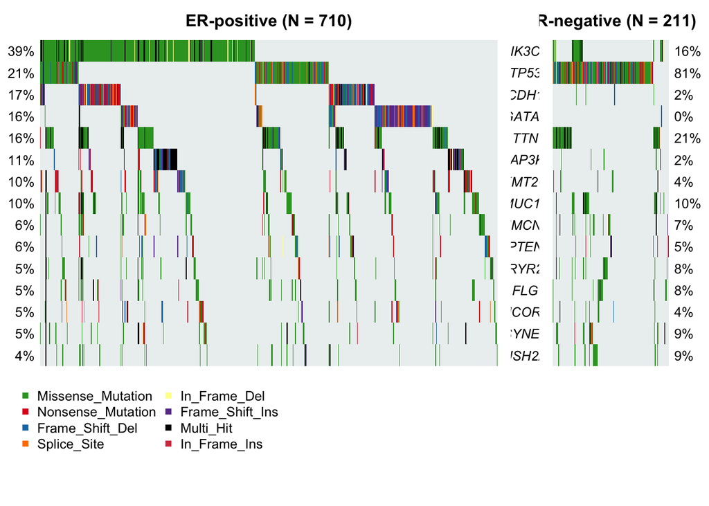

```r
coOncoplot(m1 = er_pos_maf, m2 = er_neg_maf,
           m1Name = "ER-positive", m2Name = "ER-negative",
           genes = top_genes, borderCol = NA)
```

```r
# Chosen gene: TP53 (check the plot: it should be mutated in a much larger % of ER-negative tumors; PIK3CA goes the other way).
# TP53 encodes p53, a tumor suppressor transcription factor that responds to DNA damage by arresting the cell cycle,
# triggering DNA repair, or inducing apoptosis ("guardian of the genome"). Loss of p53 lets genomically unstable cells keep dividing.
# Why the discrepancy: ER-negative tumors are enriched for the basal-like / triple-negative subtype, which is driven by
# genomic instability rather than estrogen signaling, and TP53 loss is a hallmark of that subtype. ER-positive (luminal)
# tumors depend on estrogen-receptor signaling for growth and more often carry PIK3CA/GATA3 mutations instead.
```

*3* Create a contingency table with your variable and chosen gene. Run a Fisher’s Exact Test between presence of mutations for that gene and your clinical variable. Create and save a mosaic plot. Interpret the output of the Fisher’s Exact Test in terms of the odds ratio and p-value.

```r
tp53_mutated_barcodes <- unique(MAF_object@data$Tumor_Sample_Barcode[MAF_object@data$Hugo_Symbol == "TP53"])

clin_er <- MAF_object@clinical.data[!is.na(MAF_object@clinical.data$ER_status), ]
clin_er$TP53_status <- factor(ifelse(clin_er$Tumor_Sample_Barcode %in% tp53_mutated_barcodes, "Mutated", "Wild-type"),
                              levels = c("Mutated", "Wild-type"))

contig <- table(clin_er$ER_status, clin_er$TP53_status)
contig
```

```
##
##            Mutated Wild-type
##   Positive     146       565
##   Negative     171        40
```

```r
fisher_test <- fisher.test(contig)
fisher_test
```

```
##
##  Fisher's Exact Test for Count Data
##
## data:  contig
## p-value < 2.2e-16
## alternative hypothesis: true odds ratio is not equal to 1
## 95 percent confidence interval:
##  0.03994953 0.09047912
## sample estimates:
## odds ratio
## 0.06068068
```

```r
png(file.path(fig_dir, "figures", "mosaic_ER_status_vs_TP53.png"), width = 900, height = 800, res = 120)
mosaicplot(contig, main = "ER status vs. TP53 mutation", xlab = "ER status", ylab = "TP53 status", color = c("salmon", "lightblue"))
dev.off()
```

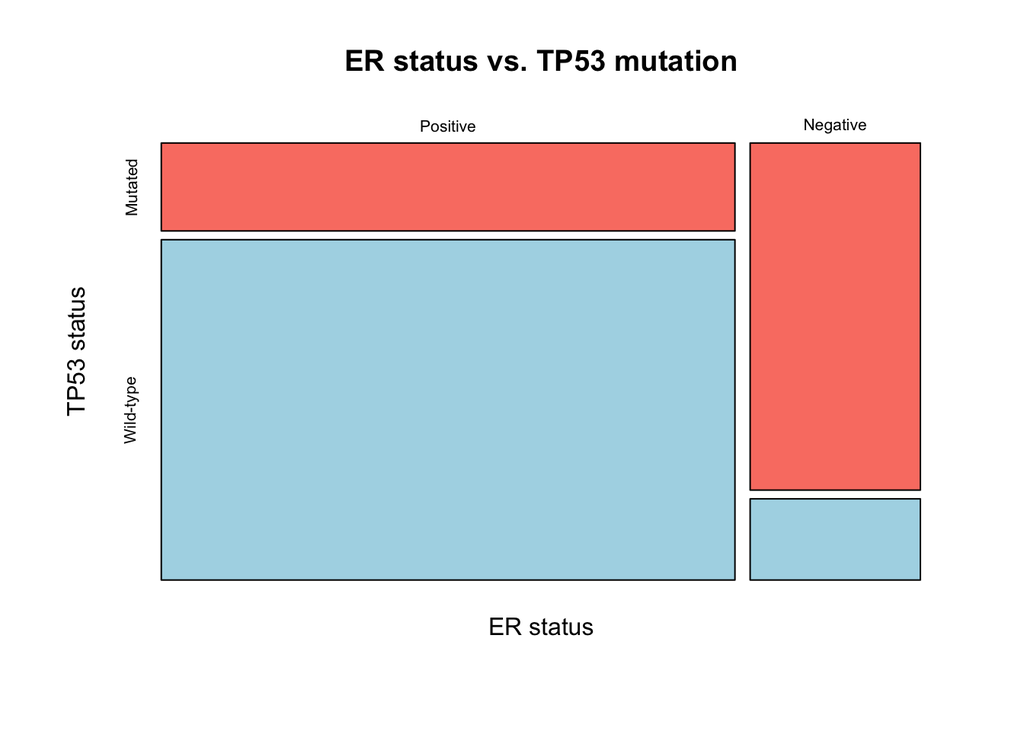

```r
mosaicplot(contig, main = "ER status vs. TP53 mutation", xlab = "ER status", ylab = "TP53 status", color = c("salmon", "lightblue"))
```

```r
cat("Fisher's exact test: odds ratio =", signif(fisher_test$estimate, 3), ", p-value =", signif(fisher_test$p.value, 3), "\n")
```

```
## Fisher's exact test: odds ratio = 0.0607 , p-value = 3.88e-58
```

```r
# Interpretation:
# Rows are ER-positive then ER-negative; columns are Mutated then Wild-type, so the odds ratio compares the odds of a TP53
# mutation in ER-positive vs ER-negative patients. An odds ratio well below 1 means ER-positive patients have much lower odds
# of carrying a TP53 mutation (equivalently, ER-negative patients have ~1/OR times higher odds). A p-value < 0.05 means this
# association is very unlikely to be due to chance, so TP53 mutation status and ER status are not independent.
```

*4* Subset your maf_object based on your chosen clinical variable and create a co-lollipop plot of your chosen gene divided between the two different clinical variable possibilities. Include descriptive names on your plot. Do you notice any difference in terms of mutations (e.g. sites, types, number) between the two populations?

```r
png(file.path(fig_dir, "figures", "colollipop_TP53_ER_pos_vs_neg.png"), width = 1400, height = 800, res = 120)
lollipopPlot2(m1 = er_pos_maf, m2 = er_neg_maf,
              m1_name = "ER-positive", m2_name = "ER-negative",
              gene = "TP53")
```

```
## Gene: TP53
```

```
## Assuming protein change information are stored under column HGVSp_Short. Use argument AACol to override if necessary.
```

```
## 8 transcripts available. Use arguments refSeqID or proteinID to manually specify tx name.
```

```
##      HGNC    refseq.ID   protein.ID aa.length
##    <char>       <char>       <char>     <num>
## 1:   TP53    NM_000546    NP_000537       393
## 2:   TP53 NM_001126112 NP_001119584       393
## 3:   TP53 NM_001126113 NP_001119585       346
## 4:   TP53 NM_001126114 NP_001119586       341
## 5:   TP53 NM_001126115 NP_001119587       261
## 6:   TP53 NM_001126116 NP_001119588       209
## 7:   TP53 NM_001126117 NP_001119589       214
## 8:   TP53 NM_001126118 NP_001119590       354
```

```
## Using longer transcript NM_000546 for now.
```

```
## Assuming protein change information are stored under column HGVSp_Short. Use argument AACol to override if necessary.
```

```
## 8 transcripts available. Use arguments refSeqID or proteinID to manually specify tx name.
```

```
##      HGNC    refseq.ID   protein.ID aa.length
##    <char>       <char>       <char>     <num>
## 1:   TP53    NM_000546    NP_000537       393
## 2:   TP53 NM_001126112 NP_001119584       393
## 3:   TP53 NM_001126113 NP_001119585       346
## 4:   TP53 NM_001126114 NP_001119586       341
## 5:   TP53 NM_001126115 NP_001119587       261
## 6:   TP53 NM_001126116 NP_001119588       209
## 7:   TP53 NM_001126117 NP_001119589       214
## 8:   TP53 NM_001126118 NP_001119590       354
```

```
## Using longer transcript NM_000546 for now.
```